# ggplot2 - 1

Eric C. Anderson

# Further fun with ggplot2

## Intro

### Prerequisites

- To work through the examples you will need a few different packages.
- Please download/install these before coming to class:
  1. install necessary packages:

     ```r
     install.packages(c("ggplot2","lubridate", "plyr", "mosaic", "mosaicData", "reshape2"))
     ```

  2. Pull the most recent version of the rep-res-course repo just before coming to class.

### Goals for this hour:

1. Discuss *wide* vs. *long* format data, and how ggplot operates on the latter
2. Introduce the `reshape2` package for converting between *wide* and *long* formats
3. Demonstrate *faceting* (creating many smaller plots whilst breaking data up over different categories)
4. Brief discussion of ggplot’s *stats* (statistical transformations)

## Wide vs Long format

### Grand Rapids, MI snow data 1893-2011

- We will explore this using the snowfall data from Grand Rapids, Michigan that is in the `mosaicData` package. (thanks to Megan S. for pointing this data set out as a good example!)
- Here we will print out a small part of it:

  ```r
  library(mosaicData)
  dim(SnowGR)  # how many rows and columns?
  ```

  ```
  ## [1] 119  15
  ```

  ```r
  head(SnowGR)  # have a look at the first few rows
  ```

  ```
  ##   SeasonStart SeasonEnd Jul Aug Sep Oct  Nov  Dec  Jan  Feb  Mar Apr May
  ## 1        1893      1894   0   0   0 0.0  8.0 24.9 12.5  6.8  4.8   2   0
  ## 2        1894      1895   0   0   0 0.0  7.5  5.3 21.5  8.0 22.5   0   0
  ## 3        1895      1896   0   0   0 0.4 23.2 15.0   NA  8.5  2.0   0   0
  ## 4        1896      1897   0   0   0 0.2  8.0  8.0  4.9 11.2 12.0   0   0
  ## 5        1897      1898   0   0   0 0.0  1.4  8.0 15.5 29.5  0.0   0   0
  ## 6        1898      1899   0   0   0 0.0 18.5 18.0 20.0  3.4 16.0   0   0
  ##   Jun Total
  ## 1   0  59.0
  ## 2   0  64.8
  ## 3   0  49.1
  ## 4   0  44.3
  ## 5   0  54.4
  ## 6   0  75.9
  ```

- We could think of a few plots we might want to make from this:
  - Average snowfall for each month
  - Distribution since 1893 of snowfall in each month,
  - etc.
- Would be great to explore this with ggplot, but there is one small problem:
  - ggplot accepts *long* format data, and `SnowGR` is in *wide* format.

### Wide vs. Long, colloquially

- Wide format data is called “wide” because it typically has a lot of columns which stretch widely across the page or your computer screen
- Long format data is called “long” because it typically has fewer columns but preserves all the same information. In order to that, it has to be longer…
- Most of us are familiar with looking at wide format data
  - It is convenient if you are doing data entry
  - It often lets you see more of the data, at one time, on your screen
- Long format data is typically less familiar to most humans
  - It seems awfully hard to get a good look at all (or most) of it
  - It seems like it would require more storage on your hard disk
  - It seems like it would be harder to enter data in a long format
  - if we have been using Microsoft Excel for too long our conceptual model for how to analyze data may never have developed beyond thinking about operating on columns as if each one were a separate entity.
- Which is better?
  - Well, there *are* some contexts where putting things in wide format is computationally efficient because you can treat data in a matrix format and to efficient matrix calculations on it.
  - However,
    1. adding data to wide format data sets is very hard 1.it is very difficult to conceive of analytical schemes that apply generally across all wide-format data sets.
    2. many tools in R want data in long format
    3. the long format for data corresponds to the *relational model* for storing data, which is the model used in most modern data bases like the SQL family of data base systems.

### ID variables, Measured variables, Values

- A more technical treatment of wide versus long data requires some terminology:
  - Identifier variables are often categorical things that cross-classify observations into categories.
  - Measured variables are the names given to properties or characteristics that you can go out and measure.
  - Values are the values that you measure are record for any particular measured variable.
- In any particular data set, what you might want to call an Identifier variables versus a Measured variables can not always be entirely clear.
  - Other people might choose to define things differently.
- However, to my mind, it is *less important* to be able to precisely recognize these three entities in every possible situation (where there might be some fuzziness about which is which)
- And it is *more important* to understand how Identifier variables, Measured variables, and Values interact and behave when we are transforming data between wide and long formats.

### Variables and values in SnowGR

- To give this some concreteness, let’s go back to the SnowGR data set.
- However, let us drop the “Total” column from it first because that is just computed from the other columns and is not “directly measured”.

  ```r
  Snow <- SnowGR[, -ncol(SnowGR)]
  ```

- Now, color it up:

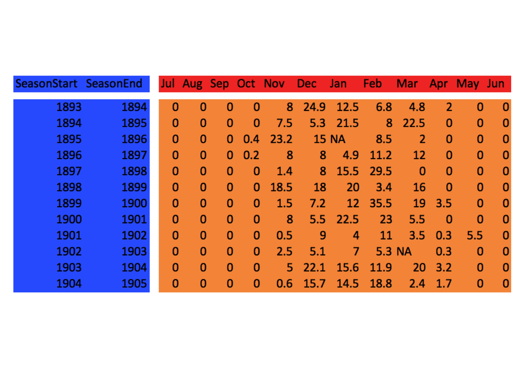

- We can think of SeasonStart and SeasonEnd as being Identifier variables. They identify which season we are in.
- The months are the Measured variables, because you go out and measure snow in each month
- And the Values occupy most of the table.

### Long Format Snow

- When something is in long format, there are columns for values of the Identifier variables and there is *one column* for the values of the values of the Measured variables and one column for the Values
- This is called a [Tidy Data](http://vita.had.co.nz/papers/tidy-data.pdf) format.
- It looks like this:

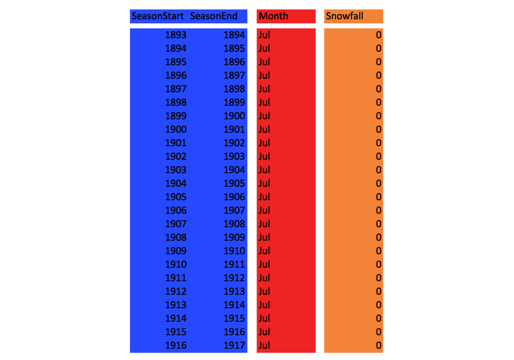

- This is the type of data frame that ggplot can deal with.

### Reshaping data

- Hadley Wickham’s package `reshape2` is perhaps the nicest utility for converting between long and wide format.
- Today we will look at the `melt` function which converts from wide to long format.
- When you “melt” a big, wide, block of data, you can stretch it easily into long format.
- `melt` takes a few arguments. The most important are these:
  - **data**: the data frame in wide format
  - id.vars: character vector of the names of the columns that are the Identifier variables
    - **NOTE**: if this is ommitted, but measure.vars is given, then all the columns that **are not** in measure.vars are assumed to be id.vars
  - measure.vars: The names of the columns that hold the Measured variables .
    - **NOTE**: if this is ommitted, but id.vars is given, then all the columns that **are not** in id.vars are assumed to be measure.vars
  - **variable.name**: What do you want to call the column of Measured variables in the long (or molten) data frame that you are making?
  - **value.name**: What do you want to call the column of Values in the long format data frame you are making?
- Let’s see it in action:

  ```r
  library(reshape2)
  longSnow <- melt(data = Snow,
                   id.vars = c("SeasonStart", "SeasonEnd"),
                   variable.name = "Month",
                   value.name = "Snowfall"
                  )
  head(longSnow)  # see what it looks like
  ```

  ```
  ##   SeasonStart SeasonEnd Month Snowfall
  ## 1        1893      1894   Jul        0
  ## 2        1894      1895   Jul        0
  ## 3        1895      1896   Jul        0
  ## 4        1896      1897   Jul        0
  ## 5        1897      1898   Jul        0
  ## 6        1898      1899   Jul        0
  ```

We are going to make some plots to underscore some particular points about ggplot

### Order of items done via factors

- Let’s make simple boxplots summarizing snowfall for each month over all the years. We want Month on the $x$-axis and we will map Snowfall to the $y$-axis.

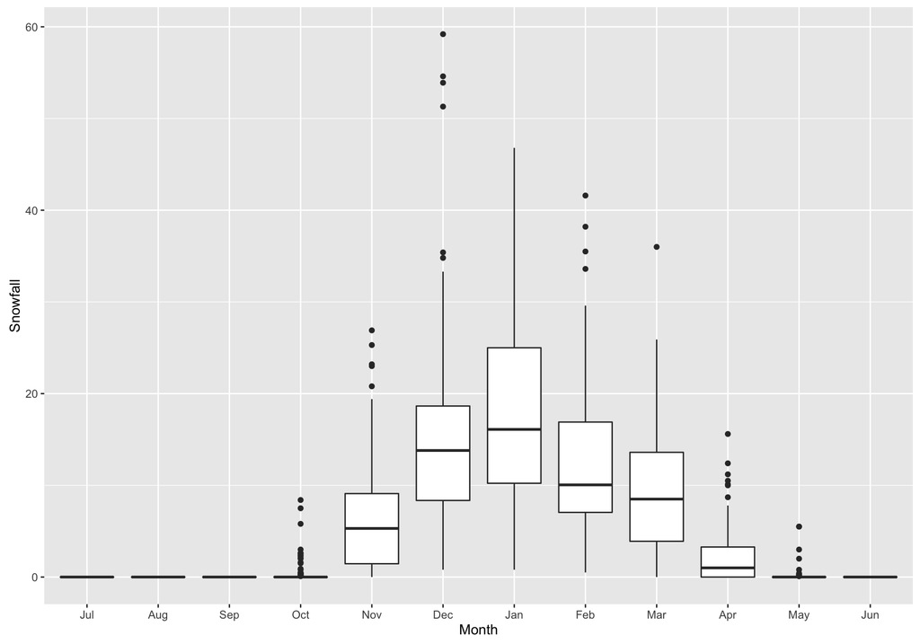

  ```r
  library(ggplot2)
  g <- ggplot(data = longSnow, mapping = aes(x = Month, y = Snowfall))
  g + geom_boxplot()
  ```

- Hey! The months came out in the right order. That is cool. Why?
  - Because, by default, `melt` made a factor of the Month column and ordered the values as they appeared in the data frame:

    ```r
    class(longSnow$Month)
    ```

    ```
    ## [1] "factor"
    ```

    ```r
    levels(longSnow$Month)
    ```

    ```
    ##  [1] "Jul" "Aug" "Sep" "Oct" "Nov" "Dec" "Jan" "Feb" "Mar" "Apr" "May"
    ## [12] "Jun"
    ```

### Colors: discrete or continuous gradient?

- When `ggplot` applies colors to things, it uses discrete values if the values of discrete (aka factors or characters) and continuous gradients if they are numeric.
- We can plot points, coloring them by SeasonStart (which is numeric…) instead of making boxplots

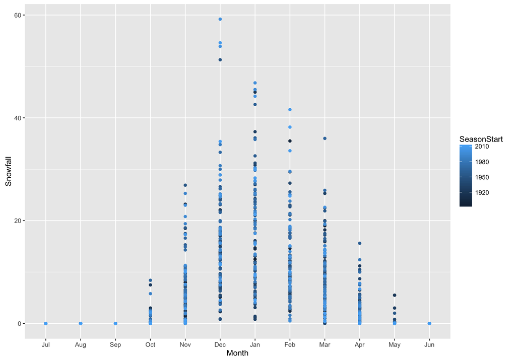

  ```r
  g + geom_point(aes(color = SeasonStart))
  ```

- If we made a factor out of SeasonStart, then each SeasonStart gets it own color (far more than would be reasonable to visualize)

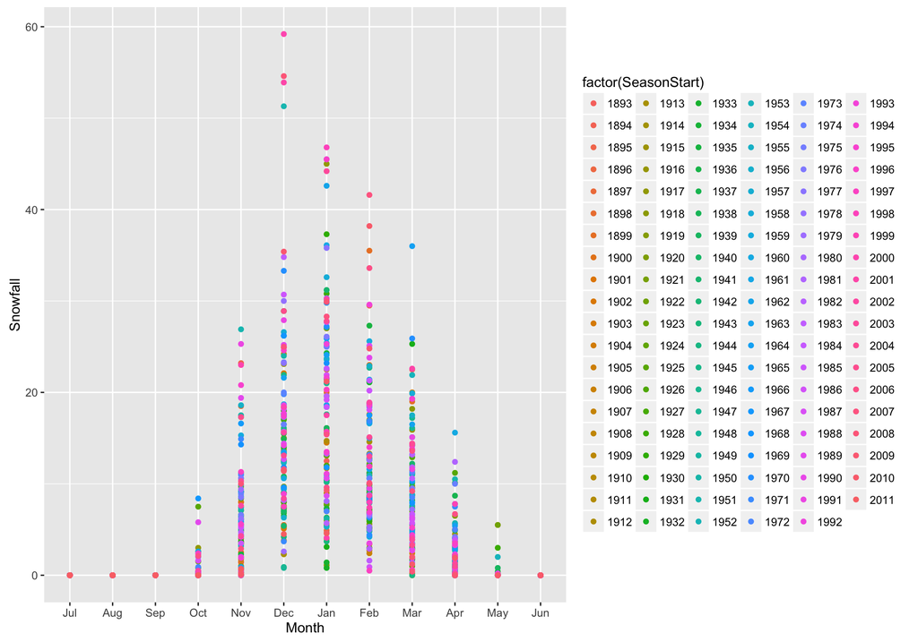

  ```r
  g + geom_point(aes(color = factor(SeasonStart)))
  ```

- So that is a little silly.

### Dealing with overplotting of points

- Notice that many points are drawn over one another. You can reveal many more points by “jittering” each one.
- This is easily achieved with `geom_jitter()` instead of `geom_point()`

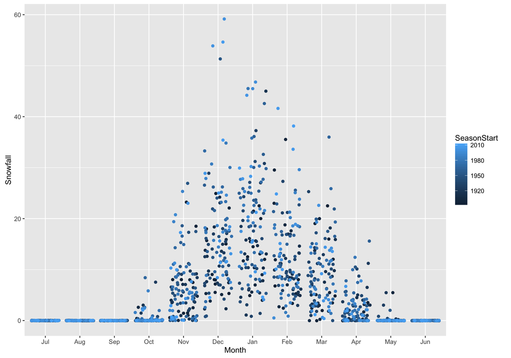

  ```r
  g + geom_jitter(aes(color = SeasonStart))
  ```

## Faceting

- Sometimes it is helpful to break your data into separate subsets (usually on the value of a factor) and make a plot that is a series of smaller plots.

### Facet Wrap

- Let’s consider looking at a histogram of Snowfall:

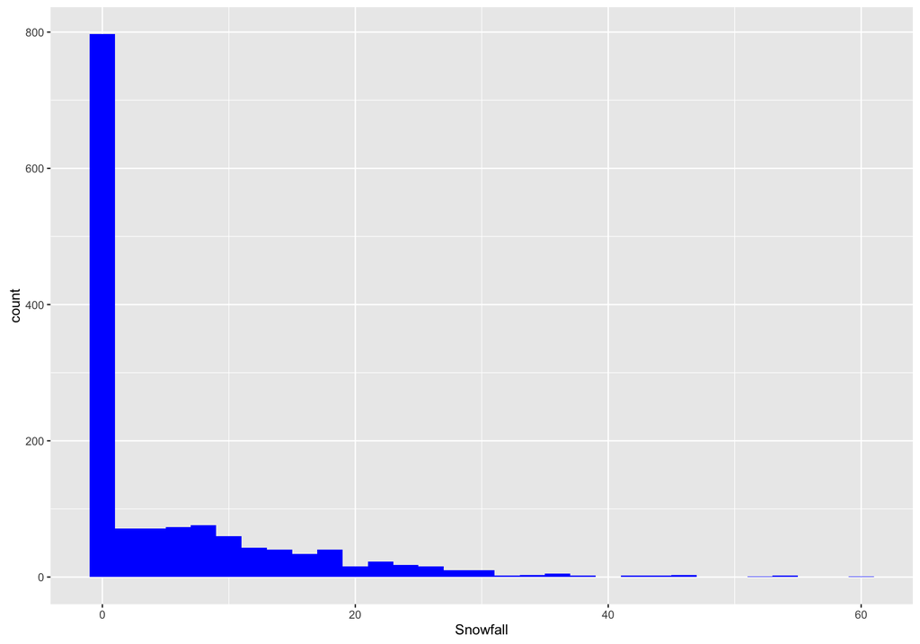

  ```r
  d <- ggplot(data = longSnow, aes(x = Snowfall)) + geom_histogram(binwidth = 2, fill = "blue")
  d
  ```

- That is nice, but it might be more interesting to see that month-by-month
- We can add a `facet_wrap` specification. We are “faceting in one long strip” but then “wrapping” it to fit on the page:

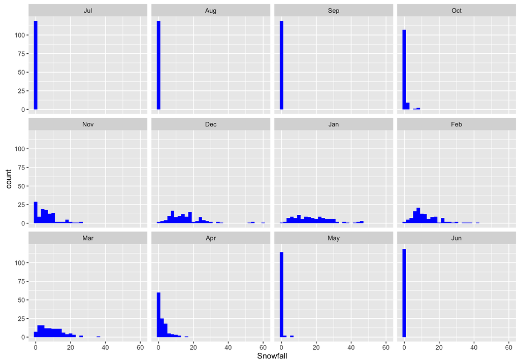

  ```r
  d + facet_wrap(~ Month, ncol = 4)
  ```

### Facet Grid

- You can also make a rows x column `facet_grid`. In fact that is where the `~` sort of specification comes from.
- Let’s imagine that we want to look at Nov through Mar snowfall, in the three different, equal-length, periods of years.

  ```r
  # make intervals
  longSnow$Interval <- cut_interval(longSnow$SeasonStart, n = 3, dig.lab = 4)

  # here is what they are:
  levels(longSnow$Interval)
  ```

  ```
  ## [1] "[1893,1932]" "(1932,1972]" "(1972,2011]"
  ```

  ```r
  # get just the months we are interesed in
  Winter <- droplevels(subset(longSnow, Month %in% c("Nov", "Dec", "Jan", "Feb", "Mar")))

  # note the use of droplevels!
  ```

- Now we can plot that with a facet_grid:

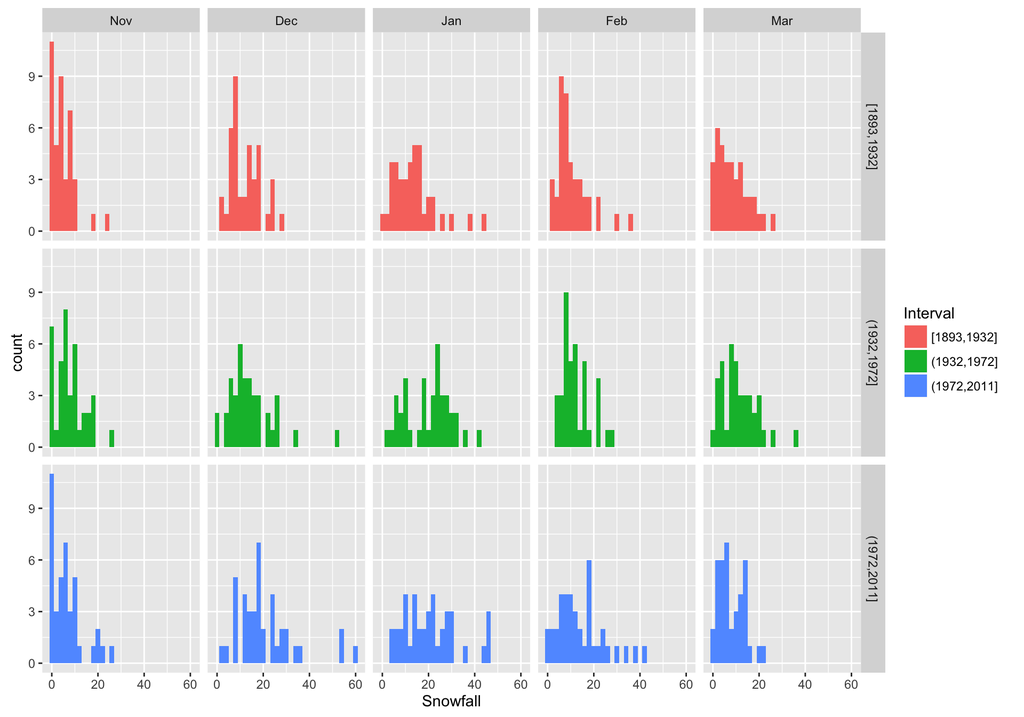

  ```r
  w <- ggplot(Winter, aes(x = Snowfall, fill = Interval)) +
    geom_histogram(binwidth = 2) +
    facet_grid(Interval ~ Month)
  w
  ```

- How about a different kind of plot that is like a continuous boxplot? Just for fun.

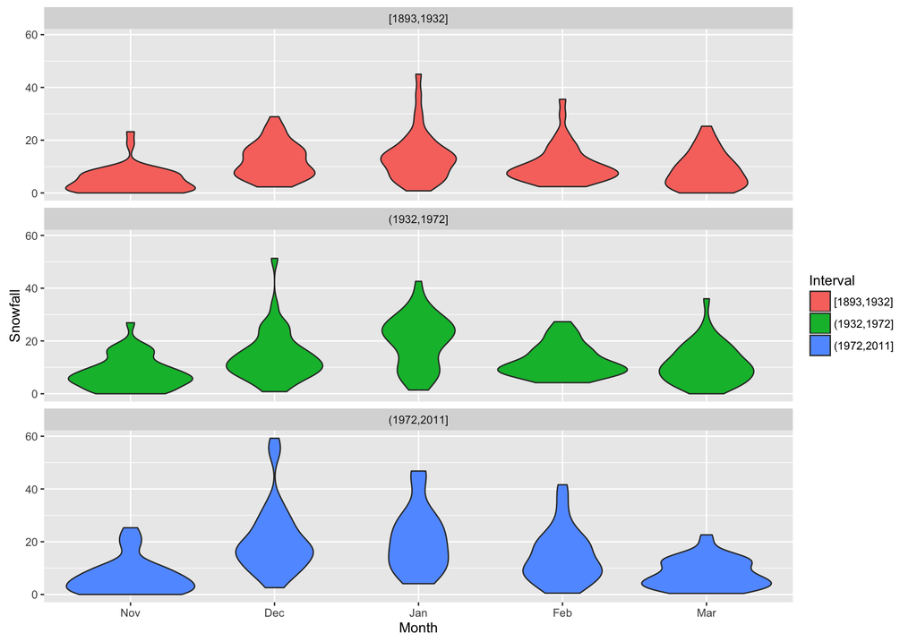

  ```r
  y <- ggplot(Winter, aes(x = Month, y = Snowfall, fill = Interval))
  y + geom_violin() + facet_wrap(~ Interval, ncol = 1)
  ```

## ggplot’s statistical transformations

- In order to create boxplots and histograms, ggplot is clearly doing some sort of statistical operations on the data.
  - For the histograms it is *binning* the data
  - For the box plots it is computing *boxplot* statistics (notches, and medians, etc)
  - For the violine plots it is computing *density* statistics.
- Each `geom_xxx()` function is associated with a default `stat_xxxx` function and vice-versa.

### Accessing the outputted values of stat_xxxx() functions

- This is not entirely trivial, but can be done by looking at the output of `ggplot_build()`

  ```r
  boing <- ggplot_build(w)
  head(boing$data[[1]])
  ```

  ```
  ##      fill  y count  x xmin xmax density    ncount ndensity PANEL group
  ## 1 #F8766D 11    11  0   -1    1  0.1375 1.0000000 80.00000     1     1
  ## 2 #F8766D  5     5  2    1    3  0.0625 0.4545455 36.36364     1     1
  ## 3 #F8766D  9     9  4    3    5  0.1125 0.8181818 65.45455     1     1
  ## 4 #F8766D  3     3  6    5    7  0.0375 0.2727273 21.81818     1     1
  ## 5 #F8766D  7     7  8    7    9  0.0875 0.6363636 50.90909     1     1
  ## 6 #F8766D  3     3 10    9   11  0.0375 0.2727273 21.81818     1     1
  ##   ymin ymax colour size linetype alpha
  ## 1    0   11     NA  0.5        1    NA
  ## 2    0    5     NA  0.5        1    NA
  ## 3    0    9     NA  0.5        1    NA
  ## 4    0    3     NA  0.5        1    NA
  ## 5    0    7     NA  0.5        1    NA
  ## 6    0    3     NA  0.5        1    NA
  ```

- This can be a fun exercise to get your head around what sort of data are produced by each of the stats (and there are quite a few of them! http://docs.ggplot2.org/current/ )